# Water Level Pipeline

## Introduction

This vignette walks through the complete water level processing pipeline using the `waterlogged` package. We use real test data from the ALBREDA RIVER station (ALBR_ST_30) as our example.

The pipeline processes raw HOBO U20 pressure logger data through these steps:

1. Read raw pressure logger files and link them to deployment metadata
2. Quality-check the barometric (air pressure) data
3. Read raw water level logger files
4. Attach the nearest barometric data to the water level data
5. Convert pressure readings (kPa) into water level (metres)
6. Run automatic quality checks on the water level data
7. Review plots and make manual corrections (ice, dry sensor, spikes)
8. Export the final clean dataset

**Why barometric data matters:** HOBO U20 loggers measure absolute pressure — that includes both the weight of water above the sensor and the weight of the atmosphere. To get just the water depth, we need to subtract the atmospheric pressure. That’s why we process barometric data first.

This vignette assumes you have already installed `waterlogged`:

```r
install.packages("pak")
pak::pkg_install("dfo-pacific-science/waterlogged")
```

## Setup

```r
library(waterlogged)
```

Define paths to the test data shipped with the package.

```r
metadata_file   <- system.file("extdata/water_level/metadata.csv", package = "waterlogged")
baro_folder     <- system.file("extdata/water_level/baro", package = "waterlogged")
level_folder    <- system.file("extdata/water_level/level", package = "waterlogged")
reference_file  <- system.file("extdata/water_level/stage_readings.csv", package = "waterlogged")
bm_survey_file <- system.file("extdata/water_level/benchmarks.csv", package = "waterlogged")
```

## Bind Raw Barometric Logger Files (v0.1)

Reads all raw HOBO CSV files from the baro folder, parses them, and links each reading to its deployment in the metadata.

Raw HOBO files are individual downloads — one CSV per field visit. This step combines them into a single tidy data frame with consistent column names and deployment info attached.

How it works:

- Reads the HOBO header (row 2) to extract the serial number (SN)
- Matches the SN + timestamp window to the metadata deployments
- Renames columns to standard names (e.g., “Abs Pres kPa” → “airpress_kPa”)
- Removes duplicate rows and trims data to deployment windows

Returns a list with two items: `[[1]]` = data frame of all combined readings, `[[2]]` = a quick-look plot.

```r
baro_bound <- bind_logger_files(
  path_to_raw_folder = baro_folder,
  metadata_path      = metadata_file
)

baro_data <- baro_bound[[1]]
baro_plot <- baro_bound[[2]]

cat("Baro data dimensions:", nrow(baro_data), "rows x", ncol(baro_data), "columns\n")
```

```
#> Baro data dimensions: 53840 rows x 7 columns
```

```r
cat("Stations found:", paste(unique(baro_data$site_station_code), collapse = ", "), "\n")
```

```
#> Stations found: ALBR_ST_30, HARP_ST_30, STIL_WE_40, TROU_ST_30
```

```r
cat("Date range:", as.character(min(baro_data$timestamp)),
    "to", as.character(max(baro_data$timestamp)), "\n")
```

```
#> Date range: 2023-10-18 14:00:00 to 2025-10-24 13:00:00
```

```r
head(baro_data)
```

```
#> # A tibble: 6 × 7
#>   sn    timestamp           airpress_kPa airtemp_C site_station_code logger_type
#>   <chr> <dttm>                     <dbl>     <dbl> <chr>             <chr>
#> 1 2081… 2023-10-18 14:00:00         91.7      7.48 ALBR_ST_30        HOBO_U20
#> 2 2081… 2023-10-18 15:00:00         91.7      7.68 ALBR_ST_30        HOBO_U20
#> 3 2081… 2023-10-18 16:00:00         91.7      7.68 ALBR_ST_30        HOBO_U20
#> 4 2081… 2023-10-18 17:00:00         91.6      7.78 ALBR_ST_30        HOBO_U20
#> 5 2081… 2023-10-18 18:00:00         91.6      7.58 ALBR_ST_30        HOBO_U20
#> 6 2081… 2023-10-18 19:00:00         91.6      7.48 ALBR_ST_30        HOBO_U20
#> # ℹ 1 more variable: metric <chr>
```

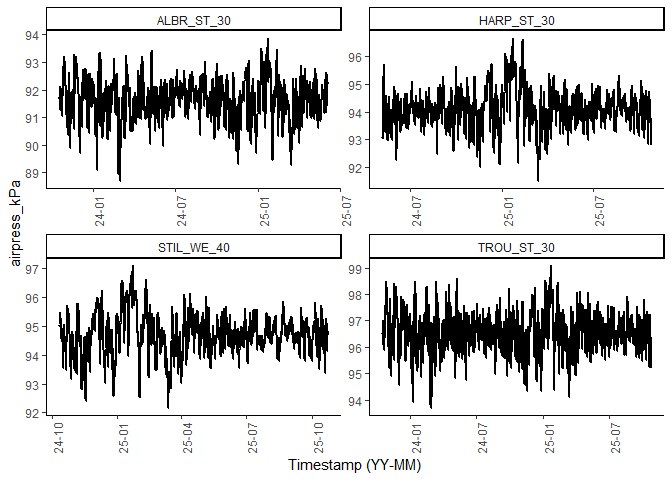

```r
baro_plot
```

## Quality-Check All Barometric Data

Runs automatic quality checks on the barometric data and flags problematic readings.

Barometric data feeds into every water level and dissolved oxygen calculation. If the baro data has errors (spikes, flatlines, or out-of-range values), those errors will propagate into the final water levels. Cleaning baro first protects everything downstream.

What it checks:

- Pressure too high (> 105 kPa) or too low (< 85 kPa)
- Temperature outside plausible range (−40 to 50 °C)
- Sudden spikes (> 1.5 kPa jump between consecutive readings)
- Flatlines (6 or more identical readings in a row)

The function never modifies the raw data. Instead, it creates new `_adj` (adjusted) columns that start as copies of the raw values. Any values that fail a check are set to `NA` in the `_adj` column. Boolean flag columns (`OUTLIER_*`, `FLAG_*`) record exactly what was checked and changed.

```r
baro_qc <- qc_barometric(
  input_data         = baro_data,
  select_station = unique(baro_data$site_station_code)[1],
  pressure_low_limit_kpa  = 85,
  pressure_high_limit_kpa = 105,
  temp_low_limit_C    = -40,
  temp_high_limit_C   = 50,
  spike_flag_kpa = 1.5,
  flatline_n        = 6
)

cat("Baro QC results:\n")
```

```
#> Baro QC results:
```

```r
cat("  Total rows:      ", nrow(baro_qc), "\n")
```

```
#>   Total rows:       14251
```

```r
cat("  Pressure outliers:", sum(baro_qc$OUTLIER_AP, na.rm = TRUE), "flagged\n")
```

```
#>   Pressure outliers: 0 flagged
```

```r
cat("  Temp outliers:    ", sum(baro_qc$OUTLIER_AT, na.rm = TRUE), "flagged\n")
```

```
#>   Temp outliers:     0 flagged
```

```r
cat("  Pressure Spikes:     ", sum(baro_qc$FLAG_SPIKE, na.rm = TRUE), "flagged\n")
```

```
#>   Pressure Spikes:      0 flagged
```

```r
cat("  Flatlines:        ", sum(baro_qc$FLAG_FLATLINE, na.rm = TRUE), "flagged\n")
```

```
#>   Flatlines:         0 flagged
```

```r
cat("  Raw NAs in airpress_kPa:     ",
    sum(is.na(baro_qc$airpress_kPa)), "\n")
```

```
#>   Raw NAs in airpress_kPa:      0
```

```r
cat("  Adjusted NAs in airpress_kPa_adj:",
    sum(is.na(baro_qc$airpress_kPa_adj)), "\n")
```

```
#>   Adjusted NAs in airpress_kPa_adj: 0
```

## Bind Raw Water Level Logger Files (v0.1)

Same as Step 1, but for the water level loggers instead of baro. The ALBR_ST_30 water level logger (HOBO U20, SN 20533550) was downloaded twice — once in April 2025 and once in October 2025. This step combines both downloads into one continuous record.

The water level logger measures the same physical quantity as the baro logger (absolute pressure in kPa), but because it’s submerged, its readings include the pressure of the water column above it. At this stage, the column is named `waterpress_kPa` to distinguish it from the baro logger’s `airpress_kPa`.

```r
level_bound <- bind_logger_files(
  path_to_raw_folder = level_folder,
  metadata_path      = metadata_file
)

level_data <- level_bound[[1]]
level_plot <- level_bound[[2]]

cat("Water level data dimensions:", nrow(level_data), "rows x",
    ncol(level_data), "columns\n")
```

```
#> Water level data dimensions: 27080 rows x 7 columns
```

```r
cat("Stations found:", paste(unique(level_data$site_station_code),
    collapse = ", "), "\n")
```

```
#> Stations found: ALBR_ST_30, CEDA_ST_30, FISH_ST_30
```

```r
head(level_data)
```

```
#> # A tibble: 6 × 7
#>   sn       timestamp           waterpress_kPa watertemp_C site_station_code
#>   <chr>    <dttm>                       <dbl>       <dbl> <chr>
#> 1 20533550 2024-10-10 10:00:00           95.1        5.76 ALBR_ST_30
#> 2 20533550 2024-10-10 11:00:00           95.0        5.86 ALBR_ST_30
#> 3 20533550 2024-10-10 12:00:00           95.2        6.06 ALBR_ST_30
#> 4 20533550 2024-10-10 13:00:00           95.1        6.27 ALBR_ST_30
#> 5 20533550 2024-10-10 14:00:00           95.0        6.37 ALBR_ST_30
#> 6 20533550 2024-10-10 15:00:00           95.1        6.57 ALBR_ST_30
#> # ℹ 2 more variables: logger_type <chr>, metric <chr>
```

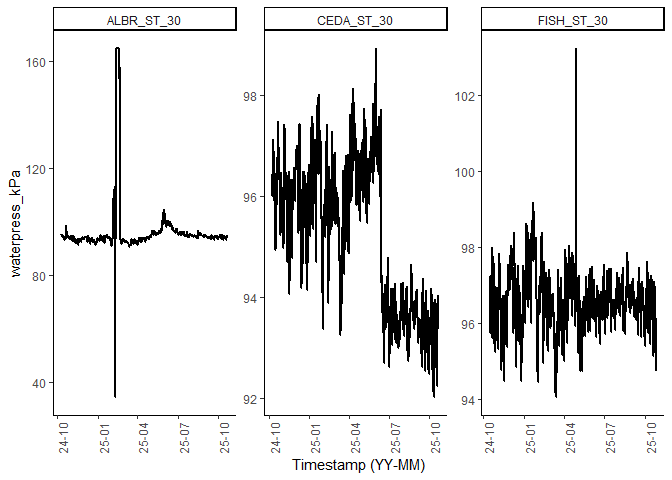

```r
level_plot
```

## Attach Barometric Data to Water Level (v0.2)

For each water level reading, finds the nearest barometric station and attaches the matching air pressure and temperature values.

To convert pressure to water depth, we need to know the atmospheric pressure at the same time. This step pairs each water level timestamp with the closest baro reading.

How “auto” selection works:

1. Calculates the geographic distance (Haversine formula) between each water level station and every barometric station in the metadata
2. Selects up to 3 nearest baro stations (within 30 km by default)
3. If multiple baro stations overlap in time, calibrates them against the closest one and combines them to fill gaps
4. Prefers the QC-adjusted values (`airpress_kPa_adj`) when available

New columns added: `airpress_kPa`, `airtemp_C`, `baro_site_stn_code`.

```r
wl_with_baro <- add_nearest_baro(
  input_data         = level_data,
  baro_data          = baro_qc,
  metric             = "water level",
  baro_site_selection = "auto",
  metadata_path      = metadata_file
)

wl_data     <- wl_with_baro[[1]]
wl_baro_plot <- wl_with_baro[[2]]

cat("After baro attach:", nrow(wl_data), "rows x", ncol(wl_data), "columns\n")
```

```
#> After baro attach: 27080 rows x 11 columns
```

```r
cat("Baro station(s) used:",
    paste(unique(wl_data$baro_site_stn_code), collapse = ", "), "\n")
```

```
#> Baro station(s) used: ALBR_ST_30, NA
```

```r
baro_na_count <- sum(is.na(wl_data$airpress_kPa))
cat("Timestamps with missing baro data:", baro_na_count,
    paste0("(", round(baro_na_count / nrow(wl_data) * 100, 1), "%)"), "\n")
```

```
#> Timestamps with missing baro data: 10194 (37.6%)
```

```r
cat("Stations in level_data:", paste(unique(level_data$site_station_code), collapse = ", "), "\n")
```

```
#> Stations in level_data: ALBR_ST_30, CEDA_ST_30, FISH_ST_30
```

```r
cat("Stations in wl_data:   ", paste(unique(wl_data$site_station_code), collapse = ", "), "\n")
```

```
#> Stations in wl_data:    ALBR_ST_30, CEDA_ST_30, FISH_ST_30
```

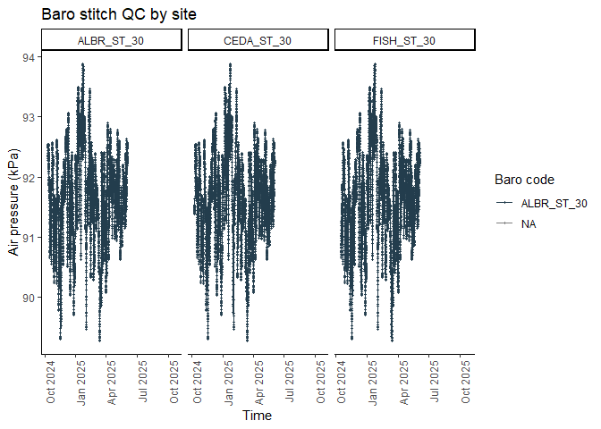

```r
wl_baro_plot
```

## Convert Pressure (kPa) to Water Level (metres) (v0.3)

Converts the raw pressure readings into actual water depth/stage in metres, using physics and a field reference measurement.

How the conversion works:

1. Calculates water density based on temperature (Kell 1975 equation)
2. Converts water pressure to a depth using: depth = pressure / (density × g)
3. Converts baro pressure to an equivalent depth the same way
4. Subtracts baro depth from water depth to get the water column height
5. Adds a constant “k” to anchor the result to a real-world reference (e.g., a staff gauge reading taken during a field visit)

The `select_measurement` parameter selects which field visit to use as the anchor point. The `reference_type` can be `"stage"` (staff gauge reading) or `"depth"` (direct depth measurement).

```r
converted <- convert_waterlevel_kPa_m(
  input_data       = wl_data,
  select_station   = "ALBR_ST_30",
  reference_data   = reference_file,
  reference_type   = "stage",
  select_measurement = 1,
  return_plots     = TRUE
)

site_wl <- converted$site_wl
ref_dat <- converted$ref_dat
wl_plot <- converted$wl_plot

cat("Converted data:", nrow(site_wl), "rows\n")
```

```
#> Converted data: 9047 rows
```

```r
cat("Water level range:",
    round(min(site_wl$waterlevel_m, na.rm = TRUE), 3), "to",
    round(max(site_wl$waterlevel_m, na.rm = TRUE), 3), "metres\n")
```

```
#> Water level range: -5.943 to 7.621 metres
```

```r
cat("Reference measurements used:", nrow(ref_dat), "\n")
```

```
#> Reference measurements used: 2
```

The interactive plot overlays the computed water level (blue line) with the field reference points (orange dots). If the logger is well-calibrated, the dots should sit on or near the line.

```r
wl_plot
```

[interactive chart not shown]

```r
head(site_wl[, c("timestamp", "waterpress_kPa", "airpress_kPa",
                  "watertemp_C", "waterlevel_m", "ref_m")])
```

```
#> # A tibble: 6 × 6
#>   timestamp           waterpress_kPa airpress_kPa watertemp_C waterlevel_m ref_m
#>   <dttm>                       <dbl>        <dbl>       <dbl>        <dbl> <dbl>
#> 1 2024-10-10 10:00:00           95.1         92.5        5.76        0.310    NA
#> 2 2024-10-10 11:00:00           95.0         92.5        5.86        0.304    NA
#> 3 2024-10-10 12:00:00           95.2         92.5        6.06        0.319    NA
#> 4 2024-10-10 13:00:00           95.1         92.5        6.27        0.309    NA
#> 5 2024-10-10 14:00:00           95.0         92.5        6.37        0.298    NA
#> 6 2024-10-10 15:00:00           95.1         92.5        6.57        0.303    NA
```

## Automatic Water Level QC

Runs automatic quality checks on the computed water level data and flags suspicious values. Even after a good conversion, the data may contain artifacts from ice formation, sensor drying out, or physical disturbances (e.g., a flood moving the logger).

What it checks:

- Negative water temperatures (< −1 °C removed; −1 to 0 °C set to 0)
- Ice conditions (water temp < 0.3 °C flagged but NOT removed)
- Step disturbances (water level jump > 0.1 m between readings)
- Dry sensor indicators (warm water temp + low pressure pattern)

**Important distinction — “flag” vs “edit”:**

- `FLAG_*` columns = “we noticed something, please review” — the data is NOT changed.
- `OUTLIER_*` columns = “we changed the data” — the `_adj` value was modified (usually set to `NA`).

```r
wl_qc <- qc_waterlevel(
  input_data     = site_wl,
  select_station = "ALBR_ST_30"
)

cat("QC results for ALBR_ST_30:\n")
```

```
#> QC results for ALBR_ST_30:
```

```r
cat("  Total rows:        ", nrow(wl_qc), "\n")
```

```
#>   Total rows:         9047
```

```r
cat("  Ice flagged:       ", sum(wl_qc$FLAG_ICE, na.rm = TRUE), "readings\n")
```

```
#>   Ice flagged:        766 readings
```

```r
cat("  Disturbance flagged:", sum(wl_qc$FLAG_DISTURBANCE, na.rm = TRUE), "readings\n")
```

```
#>   Disturbance flagged: 0 readings
```

```r
cat("  Dry flagged:       ", sum(wl_qc$FLAG_DRY, na.rm = TRUE), "readings\n")
```

```
#>   Dry flagged:        1 readings
```

```r
cat("  Temp outliers:     ", sum(wl_qc$OUTLIER_WT, na.rm = TRUE), "readings\n")
```

```
#>   Temp outliers:      464 readings
```

The QC log is stored as an attribute on the result. It records every automated action taken.

```r
qaqc_log <- attr(wl_qc, "qaqc_log")

if (!is.null(qaqc_log) && nrow(qaqc_log) > 0) {
  cat("QC log entries:\n")
  print(qaqc_log[, c("field", "action", "code", "ts_start", "ts_end")])
}
```

```
#> QC log entries:
#> # A tibble: 20 × 5
#>    field            action  code       ts_start            ts_end
#>    <chr>            <chr>   <chr>      <dttm>              <dttm>
#>  1 watertemp_C_adj  AUTO_QC OUTLIER_WT 2025-02-04 02:00:00 2025-02-05 12:00:00
#>  2 watertemp_C_adj  AUTO_QC OUTLIER_WT 2025-02-05 23:00:00 2025-02-08 13:00:00
#>  3 watertemp_C_adj  AUTO_QC OUTLIER_WT 2025-02-11 21:00:00 2025-02-13 13:00:00
#>  4 watertemp_C_adj  AUTO_QC OUTLIER_WT 2025-02-13 15:00:00 2025-02-15 13:00:00
#>  5 watertemp_C_adj  AUTO_QC OUTLIER_WT 2025-02-15 21:00:00 2025-02-16 02:00:00
#>  6 watertemp_C_adj  AUTO_QC OUTLIER_WT 2025-02-17 09:00:00 2025-02-17 10:00:00
#>  7 watertemp_C_adj  AUTO_QC FLAG_ICE   2025-01-02 06:00:00 2025-01-03 23:00:00
#>  8 watertemp_C_adj  AUTO_QC FLAG_ICE   2025-01-18 06:00:00 2025-01-18 08:00:00
#>  9 watertemp_C_adj  AUTO_QC FLAG_ICE   2025-01-18 11:00:00 2025-01-24 10:00:00
#> 10 watertemp_C_adj  AUTO_QC FLAG_ICE   2025-01-25 07:00:00 2025-01-29 21:00:00
#> 11 watertemp_C_adj  AUTO_QC FLAG_ICE   2025-02-01 06:00:00 2025-02-09 03:00:00
#> 12 watertemp_C_adj  AUTO_QC FLAG_ICE   2025-02-10 00:00:00 2025-02-10 12:00:00
#> 13 watertemp_C_adj  AUTO_QC FLAG_ICE   2025-02-10 14:00:00 2025-02-10 14:00:00
#> 14 watertemp_C_adj  AUTO_QC FLAG_ICE   2025-02-10 17:00:00 2025-02-21 14:00:00
#> 15 waterlevel_m_adj AUTO_QC FLAG_SPIKE 2025-02-04 07:00:00 2025-02-04 08:00:00
#> 16 waterlevel_m_adj AUTO_QC FLAG_SPIKE 2025-02-09 01:00:00 2025-02-09 02:00:00
#> 17 waterlevel_m_adj AUTO_QC FLAG_SPIKE 2025-02-11 23:00:00 2025-02-12 02:00:00
#> 18 waterlevel_m_adj AUTO_QC FLAG_SPIKE 2025-02-18 14:00:00 2025-02-18 15:00:00
#> 19 waterlevel_m_adj AUTO_QC FLAG_SPIKE 2025-02-20 11:00:00 2025-02-20 16:00:00
#> 20 waterlevel_m_adj AUTO_QC FLAG_DRY   2025-02-09 01:00:00 2025-02-09 01:00:00
```

## Visual Review

Creates an interactive multi-panel plot for reviewing the data. Before making manual corrections, you need to see the data. The plot shows raw vs adjusted values with flag indicators so you can decide what needs fixing.

How to use the plot:

- Light traces = raw values (original, unmodified)
- Dark traces = adjusted values (after QC corrections)
- Colored markers = flag locations (ice, dry, disturbance)
- Use the range slider at the bottom to zoom in on specific periods
- Hover over points to see exact values and timestamps

This is an iterative process: view the plot, identify a problem period, apply a correction, re-plot to verify, and repeat until satisfied.

```r
plot_qc_timeseries(
  wl_data        = wl_qc,
  baro_data      = baro_qc,
  select_station = "ALBR_ST_30",
  static         = TRUE
)
```

[output not shown]

## Manual Adjustments (Examples)

This section demonstrates the manual correction tools available. In a real project, you would apply these only after reviewing the plot and identifying specific problem periods.

Each function returns a new data frame — it does not modify the original. Always assign the result back to your working variable so corrections accumulate. The examples below use placeholder timestamps; in practice, you would pick these from the interactive plot.

### 8a. Remove ice-affected data (set to NA)

Sets `waterlevel_m_adj` and `watertemp_C_adj` to `NA` for a time window where ice was affecting the sensor. When ice forms around a pressure sensor, it creates artificial pressure readings that don’t represent the actual water level. There’s no way to correct for ice — the only option is to remove the affected readings entirely.

```r
wl_qc <- adjust_logger_NA(
   input_data       = wl_qc,
   select_station   = "ALBR_ST_30",
   metric           = "waterlevel",
   reason_to_adjust = "ice",
   timestamp_start  = "2025-02-03 00:00:00",
   timestamp_end    = "2025-02-10 00:00:00",
   manual_note      = "Ice confirmed from field visit and temperature data"
)
```

Review the timeseries to see the change.

```r
plot_qc_timeseries(
  wl_data        = wl_qc,
  baro_data      = baro_qc,
  select_station = "ALBR_ST_30",
  static         = TRUE
)
```

[output not shown]

### 8b. Correct a spike / flatline (linear interpolation)

Replaces `waterlevel_m_adj` values within a time window with a straight line drawn between the start and end points. Appropriate when the spike is clearly an artifact and the true water level was likely smooth through that period.

```r
wl_qc <- adjust_waterlevel_spike(
  input_data       = wl_qc,
  select_station   = "ALBR_ST_30",
  timestamp_start  = "2025-02-03 21:00:00",
  timestamp_end    = "2025-02-20 17:00:00",
  reason_to_adjust = "ice",
  manual_note      = "Interpolated across ice spike"
)
```

Review the timeseries to see the change.

```r
plot_qc_timeseries(
  wl_data        = wl_qc,
  baro_data      = baro_qc,
  select_station = "ALBR_ST_30",
  static         = TRUE
)
```

[output not shown]

### 8c. Correct a step offset (cable break / logger moved)

Applies a constant vertical shift to all data from a specific point onward, correcting for a sudden physical displacement. If the logger physically moves (e.g., a flood shifts the mounting bracket), all readings after that point are offset by a constant amount.

Here we will adjust the data to simulate a cable break on June 1st, and then show how to correct it.

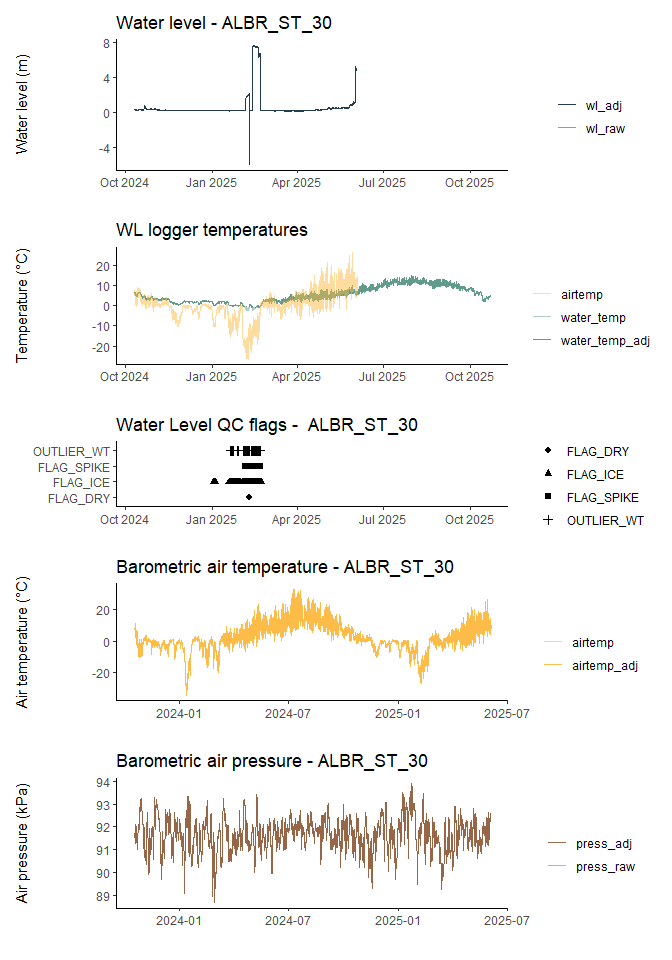

```r
wl_qc <- wl_qc|> dplyr::mutate(waterlevel_m = dplyr::case_when(timestamp > as.POSIXct("2025-06-01 00:00:00" ,tz = "UTC") ~   waterlevel_m+4,
                                                     .default = waterlevel_m ))
wl_qc$waterlevel_m_adj <- wl_qc$waterlevel_m

plot_qc_timeseries(
  wl_data        = wl_qc,
  baro_data      = baro_qc,
  select_station = "ALBR_ST_30",
  static         = TRUE)
```

```r
wl_qc <- adjust_WL_offset(
  input_data      = wl_qc,
  select_station  = "ALBR_ST_30",
  timestamp_end = "2025-06-01 01:00:00",
  timestamp_start   = "2025-06-01 00:00:00",
  manual_note     = "Cable break; logger found on streambed below stilling well"
)
```

[figure not shown]

```r
plot_qc_timeseries(
  wl_data        = wl_qc,
  baro_data      = baro_qc,
  select_station = "ALBR_ST_30",
  static         = TRUE)
```

### 8d. Multi-point drift correction

Corrects gradual sensor drift using known offsets at specific timestamps. Applies piecewise-linear interpolation between points.

```r
drift_pts <- tibble::tibble(
  timestamp = c("2024-10-10 10:00:00", "2025-06-01 00:00:00"),
  drift_m   = c(0.0, 0.12)
)

wl_qc <- wl_multipoint_correction(
  input_data     = wl_qc,
  select_station = "ALBR_ST_30",
  drift_points   = drift_pts,
  manual_note    = "Drift correction based on field survey checks"
)
```

After any manual adjustments, always re-plot to verify:

```r
plot_qc_timeseries(
  wl_data        = wl_qc,
  baro_data      = baro_qc,
  select_station = "ALBR_ST_30"
)
```

## Setting the Water-Level Datum (Optional)

`adjust_waterlevel_datum()` is the last conversion step for water level data, run after the logger series has already been cleaned. It translates a station’s relative logger stage into elevation on the station’s arbitrary operating datum, using an independent field benchmark survey rather than data derived from the logger record itself.

A benchmark survey has to exist for this step to apply — where one does, run it every time, since it’s what helps preserve continuity in the timeseries. Anchoring a series to the station’s Primary Benchmark (PBM) is what lets surveyed elevations be compared consistently over the station’s full period of record, and because the datum is tied to a physical relocatable benchmark network rather than the sensor itself, the data can be recovered if the logger or reference gauge is later lost or replaced.

It doesn’t correct the *trace* of the water-level series, QAQC and drift correction do that, it adds a constant offset, computed from the first valid survey visit, that anchors the whole series to the station’s PBM.

### A worked example

Suppose station `WL_ALBR_ST_30` has been surveyed twice: once at establishment, and once several months later as a routine check. The bm_survey table records the primary benchmark (`bm1`), a secondary benchmark (`bm2`), a tertiary benchmark (`bm3`),and the water-surface elevations observed at each visit, all in the same per-visit raw coordinate system:

```r
wl_bm_survey_ALBR_ST_30 <- tibble::tribble(
  ~site_station_code, ~survey_date,  ~survey_time, ~primary_bm, ~grade, ~bm1,  ~bm2, ~bm3,  ~water_elev_1, ~water_elev_2,
  "WL_ALBR_ST_30",     "2024-05-01", "09:00",     "bm1",       "Good", 1.500, 2.150, 1.851, 1.870, 1.871,
  "WL_ALBR_ST_30",     "2024-09-15", "10:30",     "bm1",       "Good", 1.502, 2.148, 1.852, 1.905, 1.904
)
```

And the drift-corrected logger series (output of `wl_multipoint_correction()`) looks like this, with samples bracketing each visit:

```r
station_wl_drift <- tibble::tibble(
  site_station_code = "WL_ALBR_ST_30",
  timestamp = as.POSIXct(c(
    "2024-05-01 08:45:00", "2024-05-01 09:00:00", "2024-05-01 09:15:00",
    "2024-09-15 10:15:00", "2024-09-15 10:30:00", "2024-09-15 10:45:00"
  ), tz = "UTC"),
  waterlevel_m_adj = c(0.868, 0.870, 0.873, 0.902, 0.905, 0.908)
)
```

Applying the datum:

```r
station_wl_datum <- waterlogged::adjust_waterlevel_datum(
  input_data = station_wl_drift,
  bm_survey = wl_bm_survey_ALBR_ST_30,
  select_station = "WL_ALBR_ST_30"
)

station_wl_datum
```

```
#> # A tibble: 6 × 5
#>   site_station_code timestamp           waterlevel_m_adj waterlevel_elev_m
#>   <chr>             <dttm>                         <dbl>             <dbl>
#> 1 WL_ALBR_ST_30     2024-05-01 08:45:00            0.868              100.
#> 2 WL_ALBR_ST_30     2024-05-01 09:00:00            0.87               100.
#> 3 WL_ALBR_ST_30     2024-05-01 09:15:00            0.873              100.
#> 4 WL_ALBR_ST_30     2024-09-15 10:15:00            0.902              100.
#> 5 WL_ALBR_ST_30     2024-09-15 10:30:00            0.905              100.
#> 6 WL_ALBR_ST_30     2024-09-15 10:45:00            0.908              100.
#> # ℹ 1 more variable: flag_wl_datum_applied <lgl>
```

Walking through what happened:

- The **first** visit (2024-05-01) is the datum anchor. `bm1` is pinned to `datum_elev_m = 100` (the default), and `bm2` is inferred from it: since `bm2` read 2.150 while `BM1` read 1.500 at that same visit, `bm2`’s arbitrary elevation is `100 + (2.150 - 1.500) = 100.65`.
- The anchor visit’s water-surface reading (1.870) converts to an absolute arbitrary elevation of `100 + (1.870 - 1.500) = 100.370`.
- The nearest logger sample to the anchor visit (09:00, an exact match) read `waterlevel_m_adj = 0.870`, so the constant datum offset is `100.370 - 0.870 = 99.5`.
- That single offset is added to every row for the station, giving `waterlevel_elev_m`, including the September visit’s samples – **the second visit does not create a new anchor.** It’s only used to check the benchmark network (here, `bm1` and `bm2` both came back within `bm_tolerance_m` of their original values, so no warning was raised).

### Known limitations & operating procedure

#### What is handled correctly

**The anchor is always the earliest valid visit.** `bm_survey` is sorted chronologically and the anchor is the first row where the PBM and at least one water-elevation reading are present. A later visit – no matter how much more recent, or how many more visits accumulate – never becomes the anchor, as shown above.

**A later re-survey of an existing benchmark cannot silently overwrite the datum.** When the benchmark network is built, a new inferred elevation for a benchmark that’s *already known* only triggers a warning if it disagrees by more than `bm_tolerance_m` – it does not replace the original value. A second visit can *extend* the network (new benchmarks) or *flag* a suspicious shift in an existing one, but it can never quietly re-anchor the datum.

#### Limitations

The anchor is only guaranteed to be the station’s true establishment visit if the **complete** surveying history – starting from the original establishment survey – is what’s passed into `bm_survey` / `bm_survey_path` every time the function is called. The function has no visibility outside the data it’s given, so an incremental export, a date-filtered subset, or a file that was never backfilled with the original establishment survey will cause the function to silently anchor to whichever visit happens to be earliest *in that file* – creating a new, disconnected arbitrary datum. There is currently no “anchor visit” parameter to pin the anchor explicitly.

This matters because hydrometric standards are explicit that a station’s elevations should be expressed relative to the same assumed datum for its whole period of record, and that any deliberate datum change should be logged as a formal event on the station history.

#### Operating procedure (until the code is updated)

1. **Always pass the full benchmark survey history for a station**, from establishment onward – never a filtered or incremental slice of `bm_survey`. Since the function always selects the earliest valid row itself, this alone guarantees correct anchoring with no code changes.
2. **Review `bm_tolerance_m` warning carefully**, The function keeps running regardless, using the original benchmark value – the user will need to judge whether the discrepancy reflects subsidence, benchmark disturbance, or survey error.
3. **If a station’s operating datum genuinely changes** (destroyed benchmark, deliberate re-establishment), do not run `adjust_waterlevel_datum()` once across the full record. Instead, split both `input_data` and `bm_survey` by date range at the break point, call `adjust_waterlevel_datum()` separately for each era, and keep the two resulting `waterlevel_elev_m` segments clearly labelled as being on different datums.

## Export Clean Data (v1.0)

Writes the final cleaned data to CSV files, one per station per year. This creates the deliverable output — the clean, quality-controlled water level record ready for analysis, reporting, or sharing.

What gets exported:

- `site_station_code`, `timestamp` (identifiers)
- `waterlevel_m` (raw, unmodified)
- `waterlevel_m_adj` (the final adjusted value — use this for analysis)
- `watertemp_C`, `watertemp_C_adj` (raw and adjusted temperature)
- All `FLAG_*`, `OUTLIER_*` columns (the audit trail)

Output file naming: `<output_folder>/<year>/clean/<station>_WL_<start>_<end>_v1.0.csv`

```r
write_clean_data(
  input_data            = wl_qc,
  path_to_output_folder = "processed",
  metric                = "waterlevel"
)
```

## Recap

[output not shown]

**Key columns to understand:**

- `waterlevel_m` — the raw computed water level (never modified)
- `waterlevel_m_adj` — the adjusted version (all corrections applied here)
- `FLAG_*` — “something looks off, please review” (data unchanged)
- `OUTLIER_*` — “we changed the data” (data was set to NA or corrected)

Always use `waterlevel_m_adj` for analysis. Compare it with `waterlevel_m` to see exactly what the QC process changed.